# What time should I ride my bike?

Jorge Cimentada

2018-02-12

For a few months now I’ve started developing a project on which I download live bicycle usage from the API of Bicing, the public bicycle service from the city of Barcelona. Before I started analyzing the data I wanted to harvest a reasonable amount of data to be able to get a representative sample of bicycle usage.

1. The first thing I did was to set up my Virtual Private Server (VPS) and set a `cron` job to email me every day after the scraping of the data is done. Check out a detailed tutorial on how to this here
2. The second thing I did was to set up a MySQL database in my VPS and develop a program that interacts with the Barcelona Public Bicycle System API and feeds the database on a daily basis. Check out a detailed tutorial on how I did it here

I left this program grabing biclycle data of a station close to my house only in the mornings and evenings (moments I used the bicycle) for the last 3 months. This is my first attempt to analyze this data. Please take this as a work in progress as I develop more fine-grained understanding of the data.

Here I load the libraries and connect to the database in my VPS. Note how I hide the IP of the server and the password by asking it interactively with knitr parameters.

```r
library(DBI)
library(RMySQL)
library(caret)
library(viridis)
library(tidyverse)

# REmember to KNIT with parameters

con <- dbConnect(MySQL(),
                 dbname = "bicing", # in "" quotes
                 user = "cimentadaj", # in "" quotes
                 password = params$password,
                 host = params$host) # ip of my server
```

Next, let’s grab the data with a simple query. Let’s get some columns:

1. `slots` is the number of available slots in the station
2. `bikes` is the number of available bikes in the station

These two columns are exact opposites. If the station can hold 20 bicycles and there are 8 slots available, then there’s 12 bicycles availables.

3. `status` is the status of the station. Whether `OPN` or `CLOSED`.
4. `time` is the specific date/time at which that row was returned from the API.

There’s an additional column named `error_msg` that has the error message if the API couldn’t retrieve the data. Let’s use only those which were scraped correctly. Let’s write that query and grab the data.

```r
query <-
"SELECT slots, bikes, status, time
 FROM bicing_station
 WHERE hour(time) IN ('7', '8', '9', '10', '18', '19', '20')
 AND error_msg IS NULL;"

bicing <-
  dbGetQuery(con, query) %>%
  as_tibble() %>%
  mutate(time = lubridate::ymd_hms(time),
         slots = as.numeric(slots),
         bikes = as.numeric(slots))
```

Awesome. Now we have our data set.

```r
bicing
```

```
## # A tibble: 46,399 x 4
##    slots bikes status time
##    <dbl> <dbl> <chr>  <dttm>
##  1   10.   10. OPN    2017-12-11 08:01:16
##  2   10.   10. OPN    2017-12-11 08:02:12
##  3   10.   10. OPN    2017-12-11 08:03:04
##  4   10.   10. OPN    2017-12-11 08:04:04
##  5   10.   10. OPN    2017-12-11 08:05:04
##  6    9.    9. OPN    2017-12-11 08:06:04
##  7    8.    8. OPN    2017-12-11 08:07:04
##  8    8.    8. OPN    2017-12-11 08:08:05
##  9    7.    7. OPN    2017-12-11 08:09:04
## 10    8.    8. OPN    2017-12-11 08:10:04
## # ... with 46,389 more rows
```

Let’s check if there’s any cases in which the station was not open.

```r
bicing %>%
  filter(status != "OPN")
```

```
## # A tibble: 0 x 4
## # ... with 4 variables: slots <dbl>, bikes <dbl>, status <chr>,
## #   time <dttm>
```

Empty rows, alright, station has worked fine.

Let’s explore the number of bikes comparing between mornings/evenings

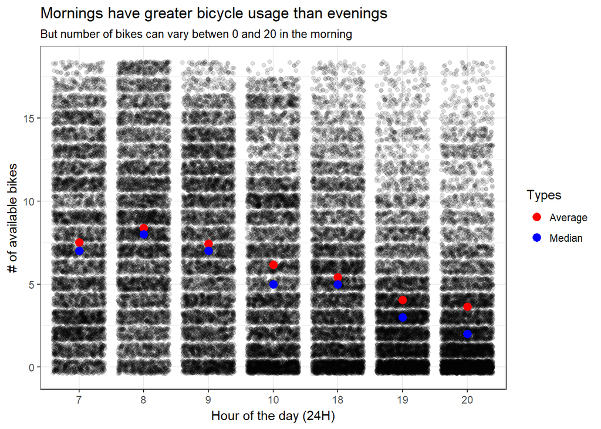

```r
summary_time <-
  bicing %>%
  group_by(hour = as.factor(lubridate::hour(time))) %>%
  summarize(Average = mean(bikes, na.rm = TRUE),
            Median = median(bikes, na.rm = TRUE)) %>%
  gather(type, value, -hour)

bicing %>%
  mutate(hour = as.factor(lubridate::hour(time))) %>%
  ggplot(aes(hour, bikes)) +
  geom_jitter(alpha = 1/8) +
  geom_point(data = summary_time,
             aes(y = value, colour = type), size = 3) +
  theme_bw() +
  labs(x = "Hour of the day (24H)",
       y = "# of available bikes",
       title = "Mornings have greater bicycle usage than evenings",
       subtitle = "But number of bikes can vary betwen 0 and 20 in the morning") +
  scale_colour_manual(name = "Types", values = c('Average' = 'red', 'Median' = 'blue'))
```

This is probably related to how Bicing fills out the stations (a few times a days a truck with bicycles passes by the station and fills them out). I think this is beginning to tell a story although perhaps it’s too early: usage in the mornings is heavy and very dynamic but as the day passes by more a more bikes are taken (either by the Bicing team or by citizens).

This gives no clear clue to the layman citizen: if it’s 8 AM, how likely am I find bikes? Let’s inspect further.